# R Notebook

This is our dataset before pre-processing.

```r
library(readxl)
CreditCard <- read_excel("C:/Users/Noni/Desktop/Datamining project/Credit Card Approvals/Dataset/CreditCard.xlsx")
print(CreditCard)
```

| Gender | Age | Debt | Married | BankCustomer | Industry | Ethnicity | YearsEmployed | PriorDefault | Employed | CreditScore | DriversLicense | Citizen | ZipCode | Income | Approved |
| --- | --- | --- | --- | --- | --- | --- | --- | --- | --- | --- | --- | --- | --- | --- | --- |
| 1 | 30.83 | 0.000 | 1 | 1 | Industrials | White | 1.250 | 1 | 1 | 1 | 0 | ByBirth | 202 | 0 | 1 |
| 0 | 58.67 | 4.460 | 1 | 1 | Materials | Black | 3.040 | 1 | 1 | 6 | 0 | ByBirth | 43 | 560 | 1 |
| 0 | 24.50 | 0.500 | 1 | 1 | Materials | Black | 1.500 | 1 | 0 | 0 | 0 | ByBirth | 280 | 824 | 1 |
| 1 | 27.83 | 1.540 | 1 | 1 | Industrials | White | 3.750 | 1 | 1 | 5 | 1 | ByBirth | 100 | 3 | 1 |
| 1 | 20.17 | 5.625 | 1 | 1 | Industrials | White | 1.710 | 1 | 0 | 0 | 0 | ByOtherMeans | 120 | 0 | 1 |
| 1 | 32.08 | 4.000 | 1 | 1 | CommunicationServices | White | 2.500 | 1 | 0 | 0 | 1 | ByBirth | 360 | 0 | 1 |
| 1 | 33.17 | 1.040 | 1 | 1 | Transport | Black | 6.500 | 1 | 0 | 0 | 1 | ByBirth | 164 | 31285 | 1 |
| 0 | 22.92 | 11.585 | 1 | 1 | InformationTechnology | White | 0.040 | 1 | 0 | 0 | 0 | ByBirth | 80 | 1349 | 1 |
| 1 | 54.42 | 0.500 | 0 | 0 | Financials | Black | 3.960 | 1 | 0 | 0 | 0 | ByBirth | 180 | 314 | 1 |
| 1 | 42.50 | 4.915 | 0 | 0 | Industrials | White | 3.165 | 1 | 0 | 0 | 1 | ByBirth | 52 | 1442 | 1 |

[output cut: 680 more lines]

Data cleaning: our data set already cleaned, there are no incomplete all colomns are filled , inconsistent each colomn have the same type or intentional data. it has only noisy data (outliers) and we removed them.

Scatter plot shows the relationship between the age and the yearsEmployed if the age increased the years also will increase.

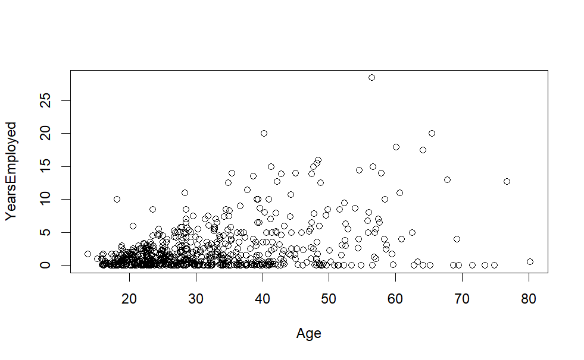

```r
#Scatter plot
with(CreditCard, plot(Age,YearsEmployed))
```

```r
#histogram
var(CreditCard$Debt)
```

```
[1] 24.78211
```

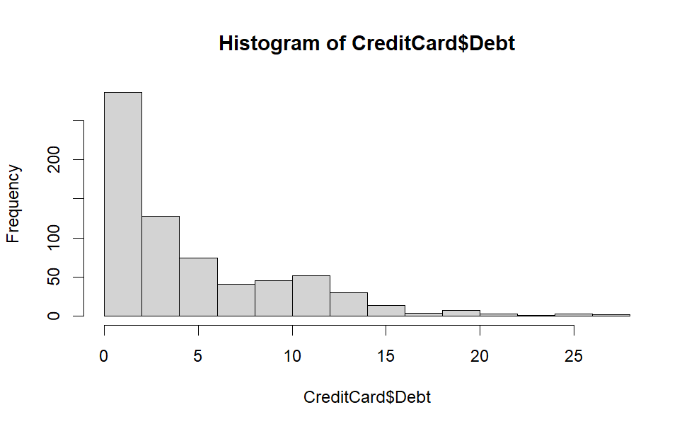

```r
hist(CreditCard$Debt)
```

Barplot shows how many applicants are citizen or not.

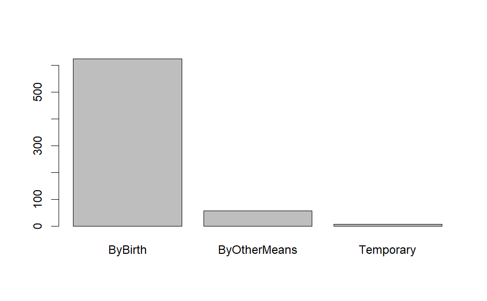

```r
#barplot
library(dplyr)
CreditCard$Citizen %>% table() %>% barplot()
```

*Data intgration(correlation analysis) first we will compare the nominal colomns with the class label.

Data intgration(correlation analysis) between the Industry colomn (nominal data type) and the class label colomn approved. We calculated the chi square = 98.323 and the df= 13 so we found that the crtical value for df 13 is = 34.528 ,the chi square is larger than the critical value we reject H0 so they are depandent and correlated .

```r
contingency_table <- table(CreditCard$Industry, CreditCard$Approved)
chi_square_result <- chisq.test(contingency_table)
print(chi_square_result)
```

```
    Pearson's Chi-squared test

data:  contingency_table
X-squared = 98.323, df = 13, p-value = 3.503e-15
```

Data intgration(correlation analysis) between the Ethnicity colomn (nominal data type) and the class label colomn approved. We calculated the chi square = 41.813 and the df= 4 so we found that the crtical value for df 4 is = 18.465 ,the chi square is larger than the critical value we reject H0 so they are depandent and correlated .

```r
contingency_table <- table(CreditCard$Ethnicity, CreditCard$Approved)
chi_square_result <- chisq.test(contingency_table)
print(chi_square_result)
```

```
    Pearson's Chi-squared test

data:  contingency_table
X-squared = 41.813, df = 4, p-value = 1.824e-08
```

```r
contingency_table <- table(CreditCard$Citizen, CreditCard$Approved)
chi_square_result <- chisq.test(contingency_table)
print(chi_square_result)
```

```
    Pearson's Chi-squared test

data:  contingency_table
X-squared = 9.1916, df = 2, p-value = 0.01009
```

after we did chi-square all the columns was highly correlated to we didn’t apply feature selection.

*Data intgration(correlation analysis) Second we will compare the numeric colomns with the class label,we found that all numeric coulmns are positive corrleated except zip code coulmn so we need to deleate it.

```r
correlation<- cor(CreditCard$Age, CreditCard$Approved)
print(correlation)
```

```
[1] 0.1640862
```

```r
correlation<- cor(CreditCard$Debt, CreditCard$Approved)
print(correlation)
```

```
[1] 0.2062937
```

```r
correlation<- cor(CreditCard$YearsEmployed, CreditCard$Approved)
print(correlation)
```

```
[1] 0.3224754
```

```r
correlation<- cor(CreditCard$CreditScore, CreditCard$Approved)
print(correlation)
```

```
[1] 0.40641
```

```r
correlation<- cor(CreditCard$Income, CreditCard$Approved)
print(correlation)
```

```
[1] 0.1756572
```

```r
correlation<- cor(CreditCard$ZipCode, CreditCard$Approved)
print(correlation)
```

```
[1] -0.09959822
```

```r
CreditCard<-subset(CreditCard,select= -ZipCode)
print(CreditCard)
```

| Gender | Age | Debt | Married | BankCustomer | Industry | Ethnicity | YearsEmployed | PriorDefault | Employed | CreditScore | DriversLicense | Citizen | Income | Approved |
| --- | --- | --- | --- | --- | --- | --- | --- | --- | --- | --- | --- | --- | --- | --- |
| 1 | 30.83 | 0.000 | 1 | 1 | Industrials | White | 1.250 | 1 | 1 | 1 | 0 | ByBirth | 0 | 1 |
| 0 | 58.67 | 4.460 | 1 | 1 | Materials | Black | 3.040 | 1 | 1 | 6 | 0 | ByBirth | 560 | 1 |
| 0 | 24.50 | 0.500 | 1 | 1 | Materials | Black | 1.500 | 1 | 0 | 0 | 0 | ByBirth | 824 | 1 |
| 1 | 27.83 | 1.540 | 1 | 1 | Industrials | White | 3.750 | 1 | 1 | 5 | 1 | ByBirth | 3 | 1 |
| 1 | 20.17 | 5.625 | 1 | 1 | Industrials | White | 1.710 | 1 | 0 | 0 | 0 | ByOtherMeans | 0 | 1 |
| 1 | 32.08 | 4.000 | 1 | 1 | CommunicationServices | White | 2.500 | 1 | 0 | 0 | 1 | ByBirth | 0 | 1 |
| 1 | 33.17 | 1.040 | 1 | 1 | Transport | Black | 6.500 | 1 | 0 | 0 | 1 | ByBirth | 31285 | 1 |
| 0 | 22.92 | 11.585 | 1 | 1 | InformationTechnology | White | 0.040 | 1 | 0 | 0 | 0 | ByBirth | 1349 | 1 |
| 1 | 54.42 | 0.500 | 0 | 0 | Financials | Black | 3.960 | 1 | 0 | 0 | 0 | ByBirth | 314 | 1 |
| 1 | 42.50 | 4.915 | 0 | 0 | Industrials | White | 3.165 | 1 | 0 | 0 | 1 | ByBirth | 1442 | 1 |

[output cut: 680 more lines]

Data cleaning (noisy outliers) We relize in Debt coulmn has wide range so it might have outliers First we detect and found the outliers from the debt colomn .

```r
#Find outliers

library(outliers)

OutDebt = outlier(CreditCard$Debt, logical =TRUE)
sum(OutDebt)
```

```
[1] 1
```

```r
Find_outlier = which(OutDebt ==TRUE, arr.ind = TRUE)
OutDebt
```

[output not shown]

[output cut: 43 more lines]

```r
Find_outlier
```

```
[1] 45
```

Second we deleted the outliers, and then printed the data set after the changes.

```r
#remove outliers

CreditCard= CreditCard[-Find_outlier,]
print(CreditCard)
```

| Gender | Age | Debt | Married | BankCustomer | Industry | Ethnicity | YearsEmployed | PriorDefault | Employed | CreditScore | DriversLicense | Citizen | Income | Approved |
| --- | --- | --- | --- | --- | --- | --- | --- | --- | --- | --- | --- | --- | --- | --- |
| 1 | 30.83 | 0.000 | 1 | 1 | Industrials | White | 1.250 | 1 | 1 | 1 | 0 | ByBirth | 0 | 1 |
| 0 | 58.67 | 4.460 | 1 | 1 | Materials | Black | 3.040 | 1 | 1 | 6 | 0 | ByBirth | 560 | 1 |
| 0 | 24.50 | 0.500 | 1 | 1 | Materials | Black | 1.500 | 1 | 0 | 0 | 0 | ByBirth | 824 | 1 |
| 1 | 27.83 | 1.540 | 1 | 1 | Industrials | White | 3.750 | 1 | 1 | 5 | 1 | ByBirth | 3 | 1 |
| 1 | 20.17 | 5.625 | 1 | 1 | Industrials | White | 1.710 | 1 | 0 | 0 | 0 | ByOtherMeans | 0 | 1 |
| 1 | 32.08 | 4.000 | 1 | 1 | CommunicationServices | White | 2.500 | 1 | 0 | 0 | 1 | ByBirth | 0 | 1 |
| 1 | 33.17 | 1.040 | 1 | 1 | Transport | Black | 6.500 | 1 | 0 | 0 | 1 | ByBirth | 31285 | 1 |
| 0 | 22.92 | 11.585 | 1 | 1 | InformationTechnology | White | 0.040 | 1 | 0 | 0 | 0 | ByBirth | 1349 | 1 |
| 1 | 54.42 | 0.500 | 0 | 0 | Financials | Black | 3.960 | 1 | 0 | 0 | 0 | ByBirth | 314 | 1 |
| 1 | 42.50 | 4.915 | 0 | 0 | Industrials | White | 3.165 | 1 | 0 | 0 | 1 | ByBirth | 1442 | 1 |

[output cut: 679 more lines]

Data cleaning (noisy outliers) As same as Debt ,Income has also huge range. Here also we detect and found the outliers from the income colomn. .

```r
#Find outliers for Income

library(outliers)

OutIncome = outlier(CreditCard$Income, logical =TRUE)
sum(OutIncome)
```

```
[1] 1
```

```r
Find_outlier = which(OutIncome ==TRUE, arr.ind = TRUE)
OutIncome
```

[output not shown]

[output cut: 43 more lines]

```r
Find_outlier
```

```
[1] 317
```

Second we deleted the outliers from the income colomn, and then printed the data set after the changes.

```r
#remove outliers

CreditCard= CreditCard[-Find_outlier,]
print(CreditCard)
```

| Gender | Age | Debt | Married | BankCustomer | Industry | Ethnicity | YearsEmployed | PriorDefault | Employed | CreditScore | DriversLicense | Citizen | Income | Approved |
| --- | --- | --- | --- | --- | --- | --- | --- | --- | --- | --- | --- | --- | --- | --- |
| 1 | 30.83 | 0.000 | 1 | 1 | Industrials | White | 1.250 | 1 | 1 | 1 | 0 | ByBirth | 0 | 1 |
| 0 | 58.67 | 4.460 | 1 | 1 | Materials | Black | 3.040 | 1 | 1 | 6 | 0 | ByBirth | 560 | 1 |
| 0 | 24.50 | 0.500 | 1 | 1 | Materials | Black | 1.500 | 1 | 0 | 0 | 0 | ByBirth | 824 | 1 |
| 1 | 27.83 | 1.540 | 1 | 1 | Industrials | White | 3.750 | 1 | 1 | 5 | 1 | ByBirth | 3 | 1 |
| 1 | 20.17 | 5.625 | 1 | 1 | Industrials | White | 1.710 | 1 | 0 | 0 | 0 | ByOtherMeans | 0 | 1 |
| 1 | 32.08 | 4.000 | 1 | 1 | CommunicationServices | White | 2.500 | 1 | 0 | 0 | 1 | ByBirth | 0 | 1 |
| 1 | 33.17 | 1.040 | 1 | 1 | Transport | Black | 6.500 | 1 | 0 | 0 | 1 | ByBirth | 31285 | 1 |
| 0 | 22.92 | 11.585 | 1 | 1 | InformationTechnology | White | 0.040 | 1 | 0 | 0 | 0 | ByBirth | 1349 | 1 |
| 1 | 54.42 | 0.500 | 0 | 0 | Financials | Black | 3.960 | 1 | 0 | 0 | 0 | ByBirth | 314 | 1 |
| 1 | 42.50 | 4.915 | 0 | 0 | Industrials | White | 3.165 | 1 | 0 | 0 | 1 | ByBirth | 1442 | 1 |

[output cut: 678 more lines]

Data transformation (normalization) The range of Debt was very wide so we did normalization on Debt to make it in smaller range.

```r
#normlization
CreditCard [, 3:3] = scale(CreditCard [, 3:3])
print(CreditCard)
```

| Gender | Age | Debt | Married | BankCustomer | Industry | Ethnicity | YearsEmployed | PriorDefault | Employed | CreditScore | DriversLicense | Citizen | Income | Approved |
| --- | --- | --- | --- | --- | --- | --- | --- | --- | --- | --- | --- | --- | --- | --- |
| 1 | 30.83 | -0.96680383 | 1 | 1 | Industrials | White | 1.250 | 1 | 1 | 1 | 0 | ByBirth | 0 | 1 |
| 0 | 58.67 | -0.04934601 | 1 | 1 | Materials | Black | 3.040 | 1 | 1 | 6 | 0 | ByBirth | 560 | 1 |
| 0 | 24.50 | -0.86394981 | 1 | 1 | Materials | Black | 1.500 | 1 | 0 | 0 | 0 | ByBirth | 824 | 1 |
| 1 | 27.83 | -0.65001346 | 1 | 1 | Industrials | White | 3.750 | 1 | 1 | 5 | 1 | ByBirth | 3 | 1 |
| 1 | 20.17 | 0.19030385 | 1 | 1 | Industrials | White | 1.710 | 1 | 0 | 0 | 0 | ByOtherMeans | 0 | 1 |
| 1 | 32.08 | -0.14397170 | 1 | 1 | CommunicationServices | White | 2.500 | 1 | 0 | 0 | 1 | ByBirth | 0 | 1 |
| 1 | 33.17 | -0.75286747 | 1 | 1 | Transport | Black | 6.500 | 1 | 0 | 0 | 1 | ByBirth | 31285 | 1 |
| 0 | 22.92 | 1.41632371 | 1 | 1 | InformationTechnology | White | 0.040 | 1 | 0 | 0 | 0 | ByBirth | 1349 | 1 |
| 1 | 54.42 | -0.86394981 | 0 | 0 | Financials | Black | 3.960 | 1 | 0 | 0 | 0 | ByBirth | 314 | 1 |
| 1 | 42.50 | 0.04425115 | 0 | 0 | Industrials | White | 3.165 | 1 | 0 | 0 | 1 | ByBirth | 1442 | 1 |

[output cut: 678 more lines]

```r
NA
```

```r
#Encoding for income
Income_mean<- mean(CreditCard$Income)
print(Income_mean)
```

```
[1] 874.9724
```

```r
CreditCard$Income[CreditCard$Income > Income_mean]<- "High"
CreditCard$Income[CreditCard$Income <= Income_mean]<- "low"
print(CreditCard)
```

| Gender | Age | Debt | Married | BankCustomer | Industry | Ethnicity | YearsEmployed | PriorDefault | Employed | CreditScore | DriversLicense | Citizen | Income | Approved |
| --- | --- | --- | --- | --- | --- | --- | --- | --- | --- | --- | --- | --- | --- | --- |
| 1 | 30.83 | -0.96680383 | 1 | 1 | Industrials | White | 1.250 | 1 | 1 | 1 | 0 | ByBirth | low | 1 |
| 0 | 58.67 | -0.04934601 | 1 | 1 | Materials | Black | 3.040 | 1 | 1 | 6 | 0 | ByBirth | low | 1 |
| 0 | 24.50 | -0.86394981 | 1 | 1 | Materials | Black | 1.500 | 1 | 0 | 0 | 0 | ByBirth | low | 1 |
| 1 | 27.83 | -0.65001346 | 1 | 1 | Industrials | White | 3.750 | 1 | 1 | 5 | 1 | ByBirth | low | 1 |
| 1 | 20.17 | 0.19030385 | 1 | 1 | Industrials | White | 1.710 | 1 | 0 | 0 | 0 | ByOtherMeans | low | 1 |
| 1 | 32.08 | -0.14397170 | 1 | 1 | CommunicationServices | White | 2.500 | 1 | 0 | 0 | 1 | ByBirth | low | 1 |
| 1 | 33.17 | -0.75286747 | 1 | 1 | Transport | Black | 6.500 | 1 | 0 | 0 | 1 | ByBirth | High | 1 |
| 0 | 22.92 | 1.41632371 | 1 | 1 | InformationTechnology | White | 0.040 | 1 | 0 | 0 | 0 | ByBirth | High | 1 |
| 1 | 54.42 | -0.86394981 | 0 | 0 | Financials | Black | 3.960 | 1 | 0 | 0 | 0 | ByBirth | low | 1 |
| 1 | 42.50 | 0.04425115 | 0 | 0 | Industrials | White | 3.165 | 1 | 0 | 0 | 1 | ByBirth | High | 1 |

[output cut: 678 more lines]

This is our Dataset after pre-processing.

```r
print(CreditCard)
```

[output not shown]

[output cut: 680 more lines]